Vamsi Gudipati

Portfolio · Generative models · October 2026

# Texture without a mean: a diffusion model for turbulent channel-flow fields, and how to measure one

A denoising diffusion model with half a million weights, trained for 22 minutes on 5,200 planes of a turbulent channel, generates fields with streaks and wall layers of the right size and a mean velocity that is flat where the real flow rises from the walls to a core. Against an independent-pixel baseline it wins on every spatial statistic; against the training ensemble it loses on all of them. No sample is a copy of a training field, and with the distance calibrated on new real fields the samples are still farther from the training set than a new field would be. A cosine noise schedule trained in full gives the mean profile its shape and cuts its error by two thirds, at the price of a fluctuation profile that is now too high, and ten deterministic sampling steps cost a fiftieth of a second per field for the linear model with no loss, and for the cosine model with all of its gain.

**Vamsi Gudipati** Denoising diffusion · DDPM and DDIM · Generative evaluation · Turbulence statistics [Repository](https://github.com/vamsigudipati/diffusion-channel-flow-fields)

0.44 vs 1.33

log-spectral distance from held-out fields at y+ ≈ 15: diffusion samples against the Gaussian baseline

0.19 vs 0.0007

mean-profile error: the samples' flat profile against a baseline with the right one

0.068 vs 0.193

mean-profile error at 40 epochs: cosine schedule, three seeds, against the linear base model

0.169 vs 0.109

distance to the nearest training field: cosine samples against new real fields of other snapshots

18× cheaper

DDIM with 10 steps against DDPM with 200, at the same profile error as 50 steps

## Objective

Every other project in this portfolio asks a network for one answer: a field, a coefficient, a forecast. A generative model is asked for something else, a distribution: new turbulent fields that are statistically like the real ones without being any of them. Such fields would serve as inflow planes, as training data, or as an ensemble for uncertainty. The question here is whether a small denoising diffusion model trained on channel-flow planes produces fields worth that use, and how that is measured. The work is three stages, each a notebook:

1. **Stage 1 — A diffusion model for channel-flow fields: training, sampling, schedules and conditioning.** A time-conditioned U-Net learns to predict the noise added to 5,200 planes of u at 200 noise levels; sampling runs the process backwards from pure noise. Then: an independent-pixel Gaussian baseline, a model conditioned on the wall shear stress, DDIM sampling with 10 to 50 steps, two noise schedules, and spectra.
2. **Stage 2 — Field statistics against held-out fields, a copying test and the cost of sampling.** Every statistic scored against the 577 held-out fields with the training fields as the real-to-real reference: profiles, the velocity distribution, spectra, two-point correlations; the distance from each sample to its nearest training field; and the cost of each sampler against its quality.
3. **Stage 3 — The cosine schedule at full training, three seeds, and a calibrated copying test.** The two questions Stage 2 left open: the cosine schedule trained for the full 40 epochs with three seeds and scored on the same held-out fields, and the copying test with a distance that means something, how far a new real field of this flow lies from the training set when its own snapshot is excluded.

The base training, 22 minutes on the Apple GPU, runs once; the four shorter trainings of the extensions, the three cosine trainings of Stage 3 and every sampler are repeated with seeds 0, 1 and 2. The data are the same channel-flow planes as my U-Net project, so this repository points at that release.

## Problem statement

Learn the distribution of u(y, x) planes from a turbulent channel at Re_τ ≈ 125 well enough to draw new ones. Then answer three things a user of such fields would ask: are the generated fields statistically right, in their mean and fluctuation profiles, their spectrum and their spatial correlation; are they new, or copies of training fields; and what does a sample cost.

[figure not shown]

**The path.** Training fields are noised by a fixed forward process; the U-Net learns to predict the noise; the reverse process from pure noise gives new fields; they are judged against held-out real fields and an independent-pixel Gaussian baseline on profiles, the velocity distribution, spectra, correlations and a copying test.

[figure not shown]

**The data.** 5,777 planes edge-padded from 201 to 208 rows (seven copies of the top-wall row, where the original text says the centreline), normalised by one global mean and standard deviation, split 5,200 / 577 at random; 99 % of the held-out fields have a neighbouring plane in training. Stage 1's own checks score against fields that include the training set; Stage 2 scores only against the 577 held out.

## Method

### Forward process, noise schedule, denoiser

The forward process adds Gaussian noise to a field in T = 200 steps with a linear variance schedule β_t from 1e-4 to 0.02; after t steps a field keeps a share ᾱ_t of its signal variance. The network is trained to predict the noise that was added, at a random step per sample, with a mean squared error; sampling starts from pure noise and removes the predicted noise step by step, adding a little fresh noise at each step (DDPM), or takes fewer, larger deterministic steps (DDIM).

[figure not shown]

**One training step.** For each of 16 fields, draw a step t and noise ε, form the noised field, predict ε, take the mean squared error. 325 batches an epoch, 40 epochs, 13,000 steps; no validation loss is computed.

[figure not shown]

**DDPM sampling.** From pure noise at t = 199, predict the noise, remove a fraction of it, add √β_t · z while t > 0, step down to 0, then undo the normalisation.

[figure not shown]

**The denoiser.** A three-level U-Net with 16, 32 and 64 filters and a 128-filter bottleneck, 508,785 weights; the step t enters through a sinusoidal embedding added at every level.

[figure not shown]

**The schedule is the hidden setting.** With the linear schedule at T = 200, ᾱ_T = 0.132: the last noise level still keeps 36 % of the field's amplitude, yet sampling starts from pure noise. The cosine schedules reach ᾱ_T ≈ 0, so their training and sampling start from the same place.

### References and measures

The Gaussian baseline draws every pixel independently from a normal distribution with the mean and standard deviation of the training fields at that height. It has the right profiles by construction and no spatial structure at all, which makes it the reference that separates the two kinds of error. Stage 2 measures, against the 577 held-out fields: the mean and RMS profile errors, the Wasserstein distance between the distributions of u at y+ ≈ 15, the log-spectral distance over streamwise modes 1 to 64 at y+ ≈ 15, at the centre and over all rows, the small-scale energy ratio, the two-point correlation and its length, and for the copying test the RMS difference between each sample and its nearest of the 5,200 training fields. The training fields themselves, scored the same way, show how far two real ensembles sit apart.

### Which device

One training step of the denoiser inside `model.fit` takes 589 ms on the CPU and 87 ms on the Apple GPU (batch 16, median of 30 steps after 10 warm-up steps), so the GPU trains everything here, one job at a time. Seeded GPU trainings repeated to every printed digit in the extensions; the base training did not repeat an earlier run of the same notebook, and the cause was not established.

## Implementation

What was run, and with what.

[output not shown]

## Results 1 — What the model generates (Stage 1)

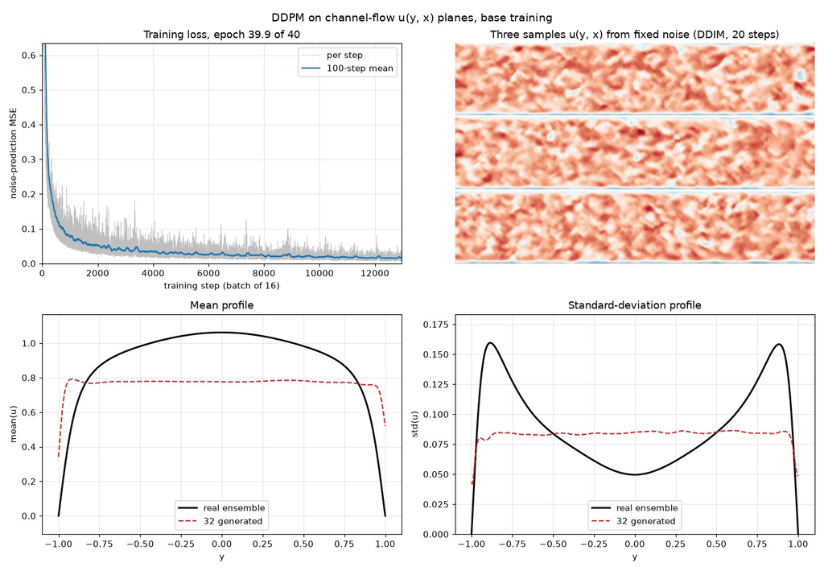

**The base training after 40 epochs.** The loss falls from 0.42 to 0.016. The three samples drawn by 20-step DDIM from fixed noise show turbulent-looking patches and thin near-wall layers. The profiles give the model away: the generated mean is nearly flat at about 0.8 across the channel, against a real profile that rises from 0 at the walls to 1.06 at the centre, and the generated fluctuation is flat at 0.085 where the real one peaks at 0.16 near the walls.

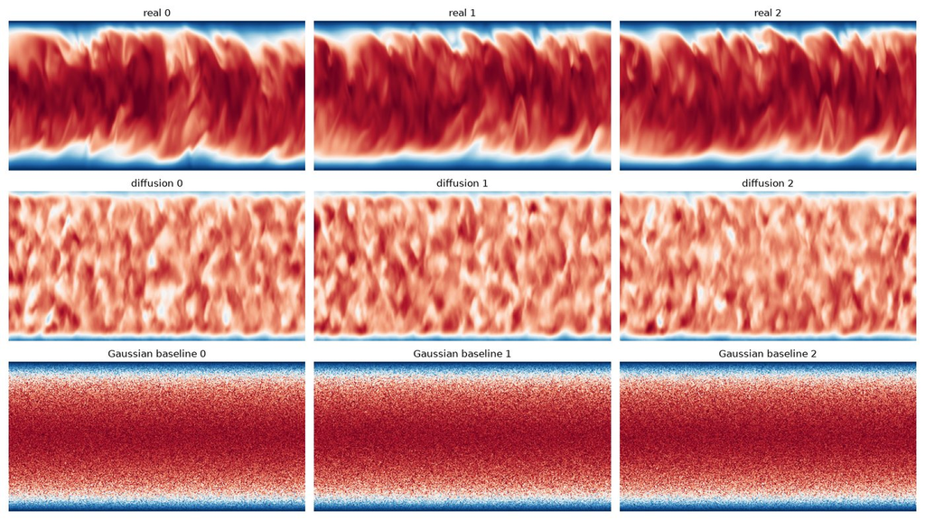

**Real, generated, baseline.** The real fields have a high-speed core with streaks and thin low-speed layers at the walls. The diffusion samples have the layers and streak-like structure of the right size, but no core: their velocity is uniform across the channel. The Gaussian baseline has the profiles and no structure. Each column is one draw.

[figure not shown]

**Two schedules, 10 epochs, three seeds.** The cosine schedule at T = 200 halves the mean-profile error of the linear one, 0.095 against 0.187, beyond the seed range; at T = 500 the gain is smaller. The 40-epoch base model is at 0.192.

[figure not shown]

**Energy in streamwise modes 1 to 8 as a share of the real energy, by band of y+.** The diffusion samples carry 0.3 to 1.7 of the real large-scale energy depending on the band, the baseline under 0.1; DDIM 50 sits below DDPM in every band.

[figure not shown]

**The base training against an earlier run of the same notebook.** Same code and settings, and the notebook seeds NumPy and TensorFlow once at the top; the first epoch's loss was 0.61 then and 0.42 now, and the end 0.0176 against 0.0162. The base training is a single run and its seed spread is not known.

## Results 2 — Right structure, wrong statistics (Stage 2)

[figure not shown]

**Distance from the held-out fields, diffusion samples against the Gaussian baseline** (log scale; 768 samples each, three seeds). On one-point statistics (profiles, the distribution of u) the baseline is closer by one to two orders of magnitude; on spatial structure (spectra, correlation) the diffusion samples are closer. Every bar is beyond the seed range.

Mean over three sampling seeds; the seed ranges are below 0.002 except the small-scale ratio (6.9 to 7.0). The training-fields column shows how far two real ensembles sit apart.

| Statistic, against the 577 held-out fields | Diffusion, DDPM 200 | Gaussian baseline | Training fields (real) |
| --- | --- | --- | --- |
| Mean-profile error | 0.193 | 0.0007 | 0.0007 |
| RMS-profile error | 0.030 | 0.0004 | 0.0004 |
| Distribution of u at y+ ≈ 15 (Wasserstein) | 0.150 | 0.016 | 0.001 |
| Log-spectral distance at y+ ≈ 15 / centre / all rows | 0.44 / 0.72 / 0.42 | 1.33 / 0.80 / 1.03 | 0.02 / 0.02 / 0.01 |
| Small-scale energy ratio at y+ ≈ 15 | 7.0 | 1,907 | 0.97 |
| Correlation length at y+ ≈ 15 / centre | 0.39 / 0.33 | 0.07 / 0.07 | 1.18 / 0.52 |
| Two-point correlation error at y+ ≈ 15 / centre | 0.12 / 0.06 | 0.14 / 0.08 | 0.01 / 0.01 |

The two references bracket the model. Against the independent-pixel baseline, which gets the profiles right by construction, the diffusion samples win on everything spatial: a spectral distance of 0.44 against 1.33 at y+ ≈ 15, a correlation length of 0.39 against 0.07, seven times the real small-scale energy against two thousand. Against the training fields, which show what a real ensemble looks like from the held-out one, they lose everywhere: a correlation length a third of the real 1.18, a spectral distance twenty times the real-to-real 0.02, and profiles two orders of magnitude off. The model has learned the texture of turbulence and not its mean.

### Copies, and the price of a sample

[figure not shown]

**Left: the copying test.** The RMS difference from each sample to its nearest of the 5,200 training fields: diffusion samples at 0.229 (median, minimum 0.217), held-out real fields at 0.026. **Right: cost against quality.** Seconds per sample on the Apple GPU against the mean-profile error: DDIM 10 is 18 times cheaper than DDPM 200 at a slightly worse profile.

Mean over three sampling seeds, 256 samples each; the three DDIM step counts are within 0.001 of each other on the profiles.

| Sampler | Network calls | Seconds per sample | Mean-profile error | RMS-profile error | Spectral distance at y+ ≈ 15 |
| --- | --- | --- | --- | --- | --- |
| DDPM 200 | 200 | 0.255 | 0.193 | 0.030 | 0.44 |
| DDIM 50 | 50 | 0.073 | 0.216 | 0.031 | 0.48 |
| DDIM 20 | 20 | 0.028 | 0.215 | 0.031 | 0.45 |
| DDIM 10 | 10 | 0.014 | 0.215 | 0.032 | 0.42 |

No sample is a copy: the closest any of the 768 comes to a training field is 0.217, eight times the median distance of a real held-out field. But that comparison needs its caveat. The held-out fields sit so close to training fields because the random split put neighbouring planes of the same snapshots into training, so 0.026 is what a near-duplicate looks like, not what a new field looks like. The test shows the samples are not copies; it does not show they are realistic new fields. The 768 samples also have only 13 distinct nearest training fields, 455 of them the same one, which says the samples cluster where the training set is dense.

On cost, the stochastic 200-step sampler is the only one that lowers the profile error, by 0.02, at 18 times the price of DDIM 10. Ten deterministic steps give the same profile as 50, and their spectral distance is not worse. For fields this far from the real profile, the sampler is not where the quality is decided.

## Results 3 — The cosine schedule at full training, and what a new field looks like (Stage 3)

### Three cosine models against the base model

Stage 1's schedule comparison was ten epochs and 64 samples scored against all fields. Stage 3 trains the denoiser with the cosine schedule for the full 40 epochs, three times, and scores 256 DDPM samples per model against the 577 held-out fields with Stage 2's statistics. Because the cosine schedule ends at ᾱ ≈ 0, the sampler's clean-field estimate is clipped to the training range at each step; applied to the base model the clipping changes nothing (0.1925 either way), so the comparison is of schedules.

[figure not shown]

**Three cosine trainings.** The noise-prediction loss ends at 0.0147, 0.0142 and 0.0125 after 40 epochs; the base model with the linear schedule ended at 0.0162. The curves are not comparable across schedules, since the noise levels they average over differ.

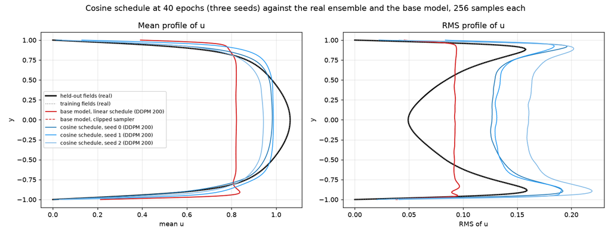

**The profiles that Stage 1 got wrong.** Left, the mean: the cosine models rise from the walls to 0.95 to 1.0 at the centre, where the real profile reaches 1.06 and the base model sits flat at 0.82. Right, the fluctuation: the cosine models now overshoot everywhere, 0.13 to 0.22 against a real profile of 0.05 to 0.16.

[figure not shown]

**Distance from the held-out fields, cosine model against base model** (log scale; cosine as the median of three model seeds with the range, base model as one training resampled, the Gaussian baseline and the real-to-real reference as before). The cosine schedule wins on the mean profile, the velocity distribution and the two-point correlation, loses on the RMS profile, and leaves the spectra where they were.

Cosine models: median over three training seeds, DDPM 200; base model: one training, 256 samples of this run, which reproduce Stage 2 to three decimals.

| Statistic, against the 577 held-out fields | Cosine, 3 seeds (range) | Base model, linear | Real-to-real |
| --- | --- | --- | --- |
| Mean-profile error | 0.068 (0.043 – 0.084) | 0.193 | 0.0007 |
| RMS-profile error | 0.052 (0.047 – 0.074) | 0.030 | 0.0004 |
| Distribution of u at y+ ≈ 15 (Wasserstein) | 0.065 (0.038 – 0.108) | 0.150 | 0.001 |
| Log-spectral distance at y+ ≈ 15 / all rows | 0.54 / 0.48 | 0.44 / 0.42 | 0.02 / 0.01 |
| Small-scale energy ratio at y+ ≈ 15 | 14.8 (13.2 – 29.9) | 6.9 | 0.97 |
| Correlation length at y+ ≈ 15 / centre | 0.65 / 0.59 | 0.39 / 0.33 | 1.18 / 0.52 |
| Two-point correlation error at y+ ≈ 15 / centre | 0.081 / 0.019 | 0.121 / 0.056 | 0.011 / 0.006 |
| Mean-profile error, DDIM 10 | 0.230 (0.196 – 0.242) | 0.215 | — |

### What a new field looks like

Stage 2's copying test compared the samples with held-out real fields that, because of the random split, each had a neighbouring plane of the same snapshot in training. Stage 3 asks the better question: how far is a held-out field from the training fields of other snapshots?

[figure not shown]

**The copying test with a calibrated distance.** The RMS difference to the nearest training field: held-out real fields against any training field (0.026, the near-duplicate distance), against other snapshots only (0.109, the green band, what a new field of this flow looks like), the three cosine models' 768 samples (0.169) and the base model's 256 (0.229).

RMS difference of u over the 201 × 384 grid to the nearest of the 5,200 training fields.

| Ensemble | Fields | Nearest-training distance, median (range) | Distinct nearest fields |
| --- | --- | --- | --- |
| Held-out real, any training field | 577 | 0.026 (0.018 – 0.052) | — |
| Held-out real, other snapshots only | 577 | 0.109 (0.090 – 0.124) | — |
| Cosine model samples, DDPM 200 | 768 | 0.169 (0.122 – 0.224) | 450 |
| Base model samples, DDPM 200 | 256 | 0.229 (0.218 – 0.239) | 13 of 768 in Stage 2 |

A new real field of this flow lies about 0.11 from the training set. No sample comes closer than the closest new field (0.090), one of the 768 cosine samples falls inside the new-field range, and the rest sit farther away: the samples are not copies, and they are still less like the training set than a new real field would be, which is the other way of saying they are not yet realistic. The cosine models' samples are closer to that band than the base model's and far more diverse: their nearest training fields are 450 distinct planes, where the base model's 768 samples had 13.

## Key observations

1. **A generative model needs two references, not one.** An independent-pixel Gaussian baseline has the right profiles and no structure; the training fields show what a real ensemble looks like. The diffusion samples beat the first on structure and lose to the second on everything, and only the pair of comparisons says so.
2. **Texture is easier than the mean.** The samples have streaks and wall layers of the right size (spectral distance 0.44 against the baseline's 1.33) and a mean profile that is flat where the real one rises from 0 to 1.06.
3. **The schedule sets the mean, and fixing it is not the whole answer.** The linear schedule never reaches pure noise (ᾱ_T = 0.132) while sampling starts there; a cosine schedule trained for the full 40 epochs cuts the mean-profile error from 0.193 to 0.068 and gives the profile its shape, but raises the fluctuation profile above the real one everywhere, leaves the spectra unchanged, and loses its gain under ten-step DDIM sampling.
4. **A copying test needs a calibrated distance.** Held-out real fields sit 0.026 from the training set because the split put their neighbouring planes in training; with their own snapshots excluded they sit 0.109, and that is what a new field looks like. No sample is closer than the closest new field, and most are farther: not copies, and not yet realistic.
5. **One training is one draw.** The base model's seed spread is unknown, and the same notebook gave a different training loss curve in an earlier run despite its seed. The three cosine trainings of Stage 3 show how wide a training spread can be, 0.043 to 0.084 on the mean profile, so every claim that rests on the base model's single training carries an unmeasured uncertainty of about that size.
6. **Ten DDIM steps are enough for the linear model and not for the cosine one.** 0.014 seconds per sample against 0.255, with the same profile error as 50 steps for the base model; with the cosine schedule the same ten steps give 0.230 against 0.068, so the step count a model can afford depends on its schedule.

## Conclusion

A small diffusion model trained for 22 minutes on 5,200 channel-flow planes learns the spatial texture of near-wall turbulence, with streaks and wall layers of the right size, and not its mean: its fields are uniform across the channel where the real flow has a high-speed core. Measured properly, against held-out fields with an independent-pixel baseline on one side and the training ensemble on the other, the samples are better than noise with the right profiles and far from real. They are not copies, and ten deterministic sampling steps produce them at a fiftieth of a second each.

Stage 3 settles the two points Stage 2 left open and opens one. The cosine schedule, trained for the full 40 epochs with three seeds, gives the mean profile its shape and cuts its error by two thirds, improves the velocity distribution and the two-point correlation beyond the seed range, and does nothing for the spectra while pushing the fluctuation profile too high; it needs the full 200-step sampler to keep any of that. With the copying distance calibrated on held-out fields from other snapshots, the samples are confirmed not to be copies and shown to be farther from the training set than a new real field, the cosine model's closer and far more diverse than the base model's.

What the stages do not establish: the base model's training-seed spread, which the cosine models suggest is not small; why the cosine models over-fluctuate, and whether a longer training or a different T corrects it; why the conditional model trades a larger error for its correlation with the wall stress; and whether a sampler between 10 and 200 steps keeps the cosine model's gain. The next steps are the base model retrained with three seeds, a DDIM step sweep for the cosine model, and a held-out spectrum and correlation at every height rather than two.

## Code, data and reproducibility

The three notebooks of the repository, each also exported as HTML with all outputs.

| Notebook | Stage |
| --- | --- |
| `01_diffusion_channel_flow.ipynb` | Stage 1 — A diffusion model for channel-flow fields: training, sampling, schedules and conditioning |
| `02_field_statistics_and_memorisation.ipynb` | Stage 2 — Field statistics against held-out fields, a copying test and the cost of sampling |
| `03_cosine_schedule_and_calibrated_copying.ipynb` | Stage 3 — The cosine schedule at full training, three seeds, and a calibrated copying test |

[output not shown]